# Lecture 14: Research Methods & Employability

Thinking ahead

Dr. Gordon Wright

g.wright@gold.ac.uk

Mon 03 Feb, 2025

## Weeks ahead

- This week - Year 1 Lab Invasion on Thursday
- Lab 14 - Analysis Planning and Open Data
- Lab 15 - Data Export, preprocessing & Overview of APA Results section
- Lab 16 - Data Analysis - Three Flavours of ANOVA (+ Assumptions & Post-hoc tests)
- Lab 17 - Results write-up, Table, Figures & style

# Careers

## Careers in Psych and Alternative Careers

[figure not shown]

## Please register

[figure not shown]

https://goldsmiths.targetconnect.net/unauth?leap=true&currentUserLocale=en_GB

## Clinical Pathway - 20,000 Psych Graduates/year

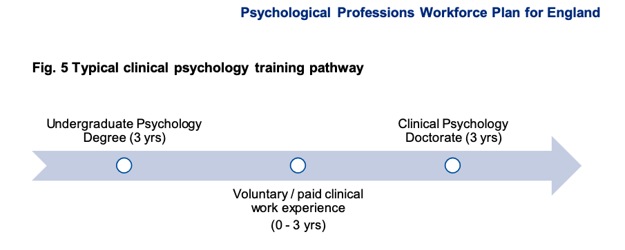

## Known Challenges

- Limited opportunity to gain ‘on the job’ experience
- **Highly** competitive and uncertain
- The vast majority of **Psych** careers require an MSc. Like another 3rd year (±5 modules (inc. RM and a dissertation). Usually 2 days per week FT.

## Embracing Innovative Research Methods

- **Explore Qualitative Research**: Engage deeply with qualitative research methods. Develop skills in ethnography, narrative analysis, and discourse analysis to bring fresh perspectives to clinical psychology.
- **Methodological Innovation**: Foster a creative approach to research methods. Break away from conventional techniques and develop novel research strategies that address complex psychological issues.
- **Utilize Theoretical Frameworks**: Integrate diverse theoretical perspectives such as feminism, poststructuralism, psychoanalysis, and Marxism into your research. This interdisciplinary approach can enrich your understanding and application of clinical psychology.

## Developing a Unique Professional Identity

- **Political and Ethical Awareness**: Cultivate an awareness of the moral and political dimensions of psychology. Understand how your work can contribute to societal change and uphold ethical standards in research.
- **Reflexivity and Critical Thinking**: Practice reflexivity in your work. Be critical of your biases and assumptions, and understand how they influence your research and clinical practice.
- **Advocacy and Empowerment**: Position yourself as an advocate for marginalized communities. Use your skills to empower individuals and groups, contributing to social justice through clinical psychology.

## Crafting a Standout Identity and Personal Statement

- **Professional Presence**: Join Linkedin, attend seminars or conferences, advertise your research skills/interest, join volunteer organisations
- **Tailored CVs**: Customize your CV for each application. Highlight relevant coursework, projects, and research experiences that align with clinical psychology.
- **Impactful Personal Statements**: Convey your passion for psychology and your commitment to pursuing a career in clinical psychology. Reflect on experiences that shaped your interest and how they prepare you for this field.
- **Showcase Skills and Achievements**: Clearly articulate your skills, especially in research methods, critical thinking, and communication. Include any awards, presentations, or publications to demonstrate your competence and dedication.

## References

- References can be a powerful addition to any application, or a weakness
- References should align with the content of your application
- A referee needs to be able to speak to Academic ability, Professional Skills, Team Work, Extra-Curricular/Voluntary work

# You can be working on all of these things NOW!

## Summer in Second Year

- GRIP and Departmental Bursaries
- Opportunities to do voluntary work
- Other options

## Here’s what they don’t tell you and maybe you don’t want to hear

- The next step on any **Psych** career is a Masters.
- Therefore, getting on the right programme is the key.
- It’s about Academic merit and the little extras.
- The best applicants I interview have a ‘Research Narrative’ (Relevant Y3 Dissertation and Proposed MSc Dissertation).
- And enough ‘experience’ to illustrate effort and engagement with the field.

## Final words on the **Psych** careers

- Don’t think of it as a ‘different’ domain to where you are now.
- Experience can be in the lab, or on a research project with vague relevance!
- Samaritans, CirclesUk, any of the virtual helplines etc. All very flexible to your time

## Alternative Careers (with HR Hiring rounds)

- Put effort into the application process and **prepare** for the interviews carefully.
- Illustrate your skills (with examples) and break down all the things you have learned here.
- Try to get a reference that highlights the same skills you are mentioning.

## Marketable Skills of a Psychology Graduate

- **DATA-SKILLS**: Ability to analyze and interpret data, identifying patterns and drawing logical conclusions from **DATA**.
- **Research Skills**: Proficiency in designing, conducting, and analyzing research, including both quantitative and qualitative methods.
- **Communication**: Strong verbal and written skills for effectively conveying complex psychological concepts to diverse audiences.
- **Empathy and Interpersonal Skills**: Exceptional understanding of human behavior and the capacity to empathize with clients from varied needs etc.
- **Problem-Solving Abilities**: Aptitude for identifying problems, generating solutions, and implementing effective strategies in **Project Management**.
- **Ethical and Cultural Awareness**: Deep understanding of ethical considerations in psychology and sensitivity to cultural differences.

## Alternative Careers (without HR Hiring rounds)

- If there is a human involved, then your Psych background is valuable. Make it count!
- Network and sell your idea/perspective/skills
- Build a portfolio or a profile
- Knock on doors and try to understand the industry
- Science the sh*t out of it!

## Last words

- Don’t be in a hurry
- If you are in a hurry, be strategic and devious
- Try to understand yourself (as much as you can)
- Talk to as many people as you can!

[figure not shown]

[figure not shown]

Research Methods Lecture 14 - Employability